# Test a Perceptual Phenomenon

Author: Sergio Comuñas Date: 31/08/2017

## 0. Background Information

In a Stroop task, participants are presented with a list of words, with each word displayed in a color of ink. The participant’s task is to say out loud the color of the ink in which the word is printed. The task has two conditions: a congruent words condition, and an incongruent words condition. In the congruent words condition, the words being displayed are color words whose names match the colors in which they are printed: for example RED, BLUE. In the incongruent words condition, the words displayed are color words whose names do not match the colors in which they are printed: for example PURPLE, ORANGE. In each case, we measure the time it takes to name the ink colors in equally-sized lists. Each participant will go through and record a time from each condition.

```python
import pandas as pd
import numpy as np
import matplotlib.pyplot as plt
from math import *

%matplotlib inline

dataset = pd.read_csv('stroopdata.csv')
```

## 1. What is our independent variable? What is our dependent variable?

- Independent variable: the words condition (congruent words or incongruent words)
- Dependent variable: the time it takes to name the ink colors in equally-sized lists

## 2. What is an appropriate set of hypotheses for this task? What kind of statistical test do you expect to perform? Justify your choices.

- Null Hypothesis (Ho): There is no significant difference in the population average response time in viewing the congruent words vs viewing the incongruent words (μi - μc = 0)
- Alternative Hypothesis (Ha): There is a significant difference, positive or negative, in the population average response times (μi - μc ≠ 0)

- We have low sample number (24 samples)
- Have no info about total population (z-test is not appropiate)

Also must be Dependent Samples test because the same subject can do the test more than once. Probably the second time he or she do have some experience and there will be better results.

## 3. Report some descriptive statistics regarding this dataset. Include at least one measure of central tendency and at least one measure of variability.

```python
# Create a statistics table around
dataset.describe()
```

|  | Congruent | Incongruent |
| --- | --- | --- |
| count | 24.000000 | 24.000000 |
| mean | 14.051125 | 22.015917 |
| std | 3.559358 | 4.797057 |
| min | 8.630000 | 15.687000 |
| 25% | 11.895250 | 18.716750 |
| 50% | 14.356500 | 21.017500 |
| 75% | 16.200750 | 24.051500 |
| max | 22.328000 | 35.255000 |

## 4. Provide one or two visualizations that show the distribution of the sample data. Write one or two sentences noting what you observe about the plot or plots.

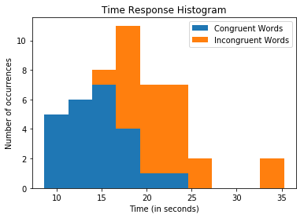

```python
#plt.hist(dataset['Congruent'], dataset['Incongruent'], histtype='step', stacked=True, fill=False)
x = dataset.values
plt.hist(x, bins = 10, stacked=True)

plt.title('Time Response Histogram')
plt.xlabel('Time (in seconds)')
plt.ylabel('Number of occurrences')
plt.legend(["Congruent Words", "Incongruent Words"])
```

## 5. Now, perform the statistical test and report your results. What is your confidence level and your critical statistic value? Do you reject the null hypothesis or fail to reject it? Come to a conclusion in terms of the experiment task. Did the results match up with your expectations?

α = .05

n = 24

df = n-1 = 23

```python
# Calculate n and df in order to use later
n = len(dataset)
dof = n - 1
print ("n =", n, "and Degrees of Freedom =", dof)

# Calculate the difference feature
dataset['Difference'] = dataset['Incongruent'] - dataset['Congruent']

# Calculate the difference from the mean feature
dataset['DFM'] = dataset['Difference'] - dataset['Difference'].mean()

# Calculate the Square Deviation from the Mean
dataset['SDFM'] = dataset['DFM'] * dataset['DFM']

# Calculate all the necessary parameters
mean = dataset['Difference'].mean(); print("Mean is", round(mean, 3))
SSD = dataset['SDFM'].sum(); print("Sum of Squares Deviation is", round(SSD, 3))
variance = SSD/(n-1); print("Variance is", round(variance, 3))

# Calculate s
s = sqrt(variance)

# Calculate t-test statistic
t = (dataset['Incongruent'].mean() - dataset['Congruent'].mean()) / (s / sqrt(n))

# Analyze results
print("")
print("T-test statistic is", round(t, 3), "that is > that t-critical (1.714)")
```

[output not shown]

We can conlude in **reject** Null hypothesis that is telling us that there is no significant difference between answering time for congruent or for incongruent color names. We are 95% confident with this approachment.

It seems to be normal because is so more difficult to answer for our brains when color and name is not matched. When more practice is done lower time for incogruent words but still being harder.